# Path Dependent Learning Dynamics of ICM PPO with Epstein Zin Utility in Time Series Reinforcement Learning

Wonjae Oh

University of North Carolina | ECON 370 Final Project

## Introduction and structure

This R Markdown file is the main driver for the project. It

- pulls and cleans data in R with `R/data_preprocessing.R`
- builds expanding-window OLS, LASSO, and decision tree benchmarks
- constructs simple trading rules from each model’s forecasts
- calls Python EZ PPO code through `reticulate`
- compares out-of-sample performance across all strategies

### **The knitted html output including the performance of the Epstein-Zin PPO model will be different each run due to path dependence!**

### Please clone https://github.com/utilityfog/EZ_Optimization/tree/main and then run Final_Project_OLS_LASSO_Tree_EZ.Rmd from within the cloned repo root!

## Packages and sources

```r
library(tidyquant)
library(dplyr)
library(tidyr)
library(lubridate)
library(glmnet)
library(ggplot2)
library(rpart)
library(rpart.plot)
library(reticulate)

# R helpers for data extraction and cleaning
source("R/data_preprocessing.R")

# Ensure the CSV for Python exists
# Always rebuild so Python sees the latest columns (including sample_set)
Total_data <- build_total_data()

cat("Sample-set counts from R (40/20/40 split):\n")
```

```
## Sample-set counts from R (40/20/40 split):
```

```r
print(table(Total_data$sample_set))
```

```
##
##       test      train validation
##        192        192         96
```

```r
cat("Sample-set proportions:\n")
```

```
## Sample-set proportions:
```

```r
print(prop.table(table(Total_data$sample_set)))
```

```
##
##       test      train validation
##        0.4        0.4        0.2
```

```r
# IMPORTANT:
# Point reticulate at the exact Python we use for EZ_Optimization.
use_python("/Users/james/Desktop/GitHub/EZ_Optimization/venv/bin/python", required = TRUE)

# Optional sanity check: see what Python reticulate is using
py_config()
```

```
## python:         /Users/james/Desktop/GitHub/EZ_Optimization/venv/bin/python
## libpython:      /opt/homebrew/opt/python@3.11/Frameworks/Python.framework/Versions/3.11/lib/python3.11/config-3.11-darwin/libpython3.11.dylib
## pythonhome:     /Users/james/Desktop/GitHub/EZ_Optimization/venv:/Users/james/Desktop/GitHub/EZ_Optimization/venv
## version:        3.11.11 (main, Dec  3 2024, 17:20:40) [Clang 16.0.0 (clang-1600.0.26.4)]
## numpy:          /Users/james/Desktop/GitHub/EZ_Optimization/venv/lib/python3.11/site-packages/numpy
## numpy_version:  2.3.5
##
## NOTE: Python version was forced by use_python() function
```

```r
# Python bridge that imports from src.train / src.eval etc.
# ez_runner.py should sit in the project root, not inside src/
# and should expose a function run_ez_eval(retrain=False) that
# internally calls src.eval.backtest_deterministic(...)
# and returns a dict with train/test stats and paths.
source_python("ez_runner.py")
```

```
## ez_runner: looking for R CSV at /Users/james/Desktop/GitHub/EZ_Optimization/data/processed/Total_data_for_python.csv
## ez_runner: using ECON370 40/20/40 split from R:
##   train rows      : 192
##   validation rows : 96
##   test rows       : 192
##   PPO training uses train + validation (first 60%),
##   PPO testing uses the last 40% (test).
## ez_runner: wrote numpy files from R CSV (with expanding normalization)
##   total rows        : 480
##   train+val rows    : 288
##     (train raw      : 192 )
##     (validation raw : 96 )
##   test rows         : 192
##   feature columns   : ['monthly_return', 'lag_return', 'GDP_g', 'Personal_Savings_Rate', 'Unemployment', 'CPI_inflation', 'FedFunds_lag1', 'Term_Spread_lag1', 'BAA_Yield_lag1', 'VIX_ret_lag1']
## ez_runner: training via src.train.main()
## Episode 0000  steps= 287  avg_r_ext=-24.028534  pol_loss=-0.0085  val_loss=0.0011
## Saved trained ActorCriticEZ to /Users/james/Desktop/GitHub/EZ_Optimization/data/processed/actor_critic_ez.pt
## Episode 0001  steps= 287  avg_r_ext=-24.056690  pol_loss=-0.0218  val_loss=0.0005
## Saved trained ActorCriticEZ to /Users/james/Desktop/GitHub/EZ_Optimization/data/processed/actor_critic_ez.pt
## Episode 0002  steps= 287  avg_r_ext=37.591469  pol_loss=-0.2384  val_loss=0.0004
## Saved trained ActorCriticEZ to /Users/james/Desktop/GitHub/EZ_Optimization/data/processed/actor_critic_ez.pt
## Episode 0003  steps= 287  avg_r_ext=-24.053953  pol_loss=-0.0613  val_loss=0.0023
## Saved trained ActorCriticEZ to /Users/james/Desktop/GitHub/EZ_Optimization/data/processed/actor_critic_ez.pt
## Episode 0004  steps= 287  avg_r_ext=-24.061609  pol_loss=-0.0645  val_loss=0.0036
## Saved trained ActorCriticEZ to /Users/james/Desktop/GitHub/EZ_Optimization/data/processed/actor_critic_ez.pt
## Episode 0005  steps= 287  avg_r_ext=-24.061502  pol_loss=-0.1721  val_loss=0.0040
## Saved trained ActorCriticEZ to /Users/james/Desktop/GitHub/EZ_Optimization/data/processed/actor_critic_ez.pt
## Episode 0006  steps= 287  avg_r_ext=-24.061062  pol_loss=-0.0028  val_loss=0.0081
## Saved trained ActorCriticEZ to /Users/james/Desktop/GitHub/EZ_Optimization/data/processed/actor_critic_ez.pt
## Episode 0007  steps= 287  avg_r_ext=-24.061192  pol_loss=-0.2152  val_loss=0.0063
## Saved trained ActorCriticEZ to /Users/james/Desktop/GitHub/EZ_Optimization/data/processed/actor_critic_ez.pt
## Episode 0008  steps= 287  avg_r_ext=-24.061409  pol_loss=-0.4265  val_loss=0.0090
## Saved trained ActorCriticEZ to /Users/james/Desktop/GitHub/EZ_Optimization/data/processed/actor_critic_ez.pt
## Episode 0009  steps= 287  avg_r_ext=38.302246  pol_loss=-0.2209  val_loss=0.0054
## Saved trained ActorCriticEZ to /Users/james/Desktop/GitHub/EZ_Optimization/data/processed/actor_critic_ez.pt
## run_ez_pipeline returned:
## {'proc_dir': '/Users/james/Desktop/GitHub/EZ_Optimization/data/processed', 'model_path': '/Users/james/Desktop/GitHub/EZ_Optimization/data/processed/actor_critic_ez.pt', 'retrained': True, 'num_episodes': 1, 'used_r_csv': True, 'feature_dim': 10, 'n_obs_train': 288, 'feature_cols': ['monthly_retu…
```

## Variable reasoning

Our target is next month S&P 500 simple return (`predicting_return`). Predictors combine macro, rates, credit, volatility and momentum, and must reach at least 10 variables from 4 or more data sources. Here we use

- current and lagged monthly S&P 500 returns (market momentum)
- real GDP growth rate
- personal savings rate
- unemployment rate
- CPI inflation
- effective federal funds rate
- 10 year minus 2 year Treasury term spread
- BAA corporate bond yield
- VIX monthly return

Economic stories:

- macro growth and savings capture aggregate demand and buffer stock behavior
- unemployment and spreads proxy for business cycle risk
- inflation and policy rates describe the nominal environment
- VIX and past returns capture risk appetite and trend following

All of these are monthly series either from FRED or market data.

## Data extraction, cleaning, and combining (R)

All data work lives in `R/data_preprocessing.R`. This Rmd only calls a single function and checks the result.

```r
glimpse(Total_data)
```

```
## Rows: 480
## Columns: 13
## $ predicting_date       <date> 1985-01-01, 1985-02-01, 1985-03-01, 1985-04-01,…
## $ predicting_return     <dbl> 7.4085141, 0.8628780, -0.2870013, -0.4594276, 5.…
## $ monthly_return        <dbl> 2.2374396, 7.4085141, 0.8628780, -0.2870013, -0.…
## $ lag_return            <dbl> -1.5112256, 2.2374396, 7.4085141, 0.8628780, -0.…
## $ GDP_g                 <dbl> 7.1, 3.9, 3.9, 3.9, 3.3, 3.3, 3.3, 3.9, 3.9, 3.9…
## $ Personal_Savings_Rate <dbl> 11.1, 10.2, 8.9, 8.6, 9.8, 11.0, 9.6, 9.1, 8.1, …
## $ Unemployment          <dbl> 7.3, 7.3, 7.2, 7.2, 7.3, 7.2, 7.4, 7.4, 7.1, 7.1…
## $ CPI_inflation         <dbl> 0.19011413, 0.18975338, 0.18939400, 0.56603925, …
## $ FedFunds_lag1         <dbl> 9.43, 8.38, 8.35, 8.50, 8.58, 8.27, 7.97, 7.53, …
## $ Term_Spread_lag1      <dbl> 0.73, 0.73, 0.73, 1.25, 1.13, 1.21, 1.45, 1.45, …
## $ BAA_Yield_lag1        <dbl> 13.48, 13.40, 13.26, 13.23, 13.69, 13.51, 13.15,…
## $ VIX_ret_lag1          <dbl> 47.09977, 47.09977, 47.09977, 47.09977, 47.09977…
## $ sample_set            <chr> "train", "train", "train", "train", "train", "tr…
```

```r
summary(Total_data$predicting_return)
```

```
##    Min. 1st Qu.  Median    Mean 3rd Qu.    Max.
## -21.763  -1.737   1.217   0.843   3.597  13.177
```

```r
cat("Any NA? ", anyNA(Total_data), "\n")
```

```
## Any NA?  FALSE
```

```r
cat("Number of rows: ", nrow(Total_data), "\n")
```

```
## Number of rows:  480
```

```r
range(Total_data$predicting_date)
```

```
## [1] "1985-01-01" "2024-12-01"
```

By construction, `Total_data` should have

- `predicting_date` from 1985-01-01 to 2024-12-01
- 480 rows (40 years times 12 months)
- columns: `predicting_date`, `predicting_return` and at least 10 predictors

If any of these checks fail, fix `build_total_data()` before moving on.

## Simple exploration

```r
# pairwise correlations between future return and numeric predictors
numeric_preds <- Total_data %>%
  dplyr::select(-predicting_date, -predicting_return) %>%
  dplyr::select(where(is.numeric))

cors <- cor(
  Total_data$predicting_return,
  numeric_preds
)

cors
```

```
##      monthly_return lag_return       GDP_g Personal_Savings_Rate Unemployment
## [1,]    0.001383613 -0.0620363 0.007191952             0.1273462    0.0745316
##      CPI_inflation FedFunds_lag1 Term_Spread_lag1 BAA_Yield_lag1 VIX_ret_lag1
## [1,]    0.02200088    0.04186415      -0.02130647    0.007504445   0.05040679
```

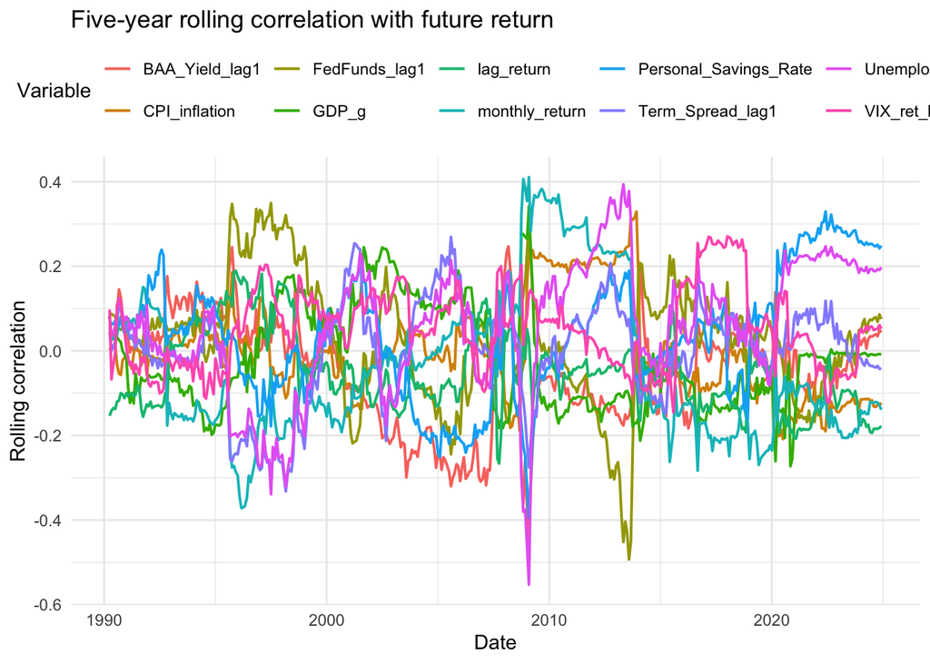

```r
# 5 year (60-month) rolling correlations
Rolling_corr <- Total_data %>%
  # keep date plus numeric predictors only, drop target
  dplyr::select(predicting_date, where(is.numeric)) %>%
  dplyr::select(-predicting_return)

var_names <- names(Rolling_corr)[names(Rolling_corr) != "predicting_date"]
Rolling_corr[, var_names] <- NA_real_

window_len <- 60

for (i in 1:(nrow(Total_data) - window_len + 1)) {
  idx <- i:(i + window_len - 1)
  Rolling_corr$predicting_date[i + window_len - 1] <- Total_data$predicting_date[i + window_len - 1]
  Rolling_corr[i + window_len - 1, var_names] <- cor(
    Total_data$predicting_return[idx],
    Total_data[idx, var_names]
  )
}

Rolling_corr_long <- Rolling_corr %>%
  tidyr::drop_na() %>%
  tidyr::pivot_longer(
    -predicting_date,
    names_to = "Variable",
    values_to = "rolling_corr"
  )

ggplot(Rolling_corr_long,
       aes(x = predicting_date, y = rolling_corr, color = Variable)) +
  geom_line(linewidth = 0.7) +
  theme_minimal() +
  labs(
    title = "Five-year rolling correlation with future return",
    x = "Date",
    y = "Rolling correlation"
  ) +
  theme(legend.position = "top")
```

## Expanding-window OLS, LASSO, and decision tree (R side)

We follow the course structure. For calendar year `i` between 2009 and 2024,

- **OLS** training uses all data from 1985 up to year `i - 1`.
- **LASSO** and **decision tree** use an expanding training/validation split:
  - training: 1985 up to `i - 9` (inclusive)
  - validation: `i - 8` to `i - 1`
- Out-of-sample test is the full year `i`.

```r
# Drop sample_set entirely from modeling data to avoid factor level issues
Total_model <- Total_data %>%
  dplyr::select(-sample_set)

# define predictors explicitly (everything except date and target)
pred_vars <- setdiff(names(Total_model), c("predicting_date", "predicting_return"))

lambda_grid <- 10 ^ seq(-3, 3, length.out = 40)
cv_errors_lasso  <- numeric(length(lambda_grid))

# modest grid for decision-tree cp
cp_grid <- c(0.001, 0.005, 0.01, 0.02, 0.05)
cv_errors_tree <- numeric(length(cp_grid))

Testing_result <- Total_data %>%
  dplyr::filter(lubridate::year(predicting_date) >= 2009) %>%
  dplyr::transmute(
    predicting_date,
    actual_return       = predicting_return,
    fitted_return_OLS   = NA_real_,
    fitted_return_LASSO = NA_real_,
    fitted_return_Tree  = NA_real_
  )

for (i_year in 2009:2024) {
  # work only with Total_model (no sample_set)
  train_ols <- Total_model %>%
    dplyr::filter(lubridate::year(predicting_date) < i_year)

  # LASSO / tree training and validation split
  train_start <- 1985
  val_start   <- i_year - 8  # 8-year validation window

  train_lasso <- Total_model %>%
    dplyr::filter(
      lubridate::year(predicting_date) >= train_start,
      lubridate::year(predicting_date) <  val_start
    )

  val_lasso <- Total_model %>%
    dplyr::filter(
      lubridate::year(predicting_date) >= val_start,
      lubridate::year(predicting_date) <  i_year
    )

  test_x <- Total_model %>%
    dplyr::filter(lubridate::year(predicting_date) == i_year) %>%
    dplyr::select(dplyr::all_of(pred_vars))

  # --- LASSO tuning on validation set ---
  x_train <- train_lasso %>%
    dplyr::select(dplyr::all_of(pred_vars)) %>%
    as.matrix()
  y_train <- train_lasso$predicting_return

  x_val <- val_lasso %>%
    dplyr::select(dplyr::all_of(pred_vars)) %>%
    as.matrix()
  y_val <- val_lasso$predicting_return

  for (j in seq_along(lambda_grid)) {
    m_lasso <- glmnet(x_train, y_train, alpha = 1, lambda = lambda_grid[j])
    y_pred_val <- as.numeric(predict(m_lasso, newx = x_val))
    cv_errors_lasso[j] <- mean((y_val - y_pred_val) ^ 2)
  }

  best_lambda <- lambda_grid[which.min(cv_errors_lasso)]

  x_tv <- rbind(x_train, x_val)
  y_tv <- c(y_train, y_val)

  m_lasso_best <- glmnet(x_tv, y_tv, alpha = 1, lambda = best_lambda)

  x_test_mat <- as.matrix(test_x)
  y_pred_test_lasso <- as.numeric(predict(m_lasso_best, newx = x_test_mat))

  # --- Decision tree tuning on validation set ---
  # Note: drop predicting_date in the DATA, not the formula
  train_lasso_tree <- train_lasso %>% dplyr::select(-predicting_date)
  val_lasso_tree   <- val_lasso   %>% dplyr::select(-predicting_date)

  for (k in seq_along(cp_grid)) {
    tree_k <- rpart(
      predicting_return ~ .,
      data = train_lasso_tree,
      method = "anova",
      control = rpart.control(cp = cp_grid[k], minsplit = 20)
    )
    y_pred_val_tree <- predict(tree_k, newdata = val_lasso_tree)
    cv_errors_tree[k] <- mean((y_val - y_pred_val_tree) ^ 2)
  }

  best_cp <- cp_grid[which.min(cv_errors_tree)]

  # Refit tree on combined train+val with best_cp, still without predicting_date
  trainval_tree <- dplyr::bind_rows(train_lasso, val_lasso) %>%
    dplyr::select(-predicting_date)

  m_tree_best <- rpart(
    predicting_return ~ .,
    data = trainval_tree,
    method = "anova",
    control = rpart.control(cp = best_cp, minsplit = 20)
  )

  # test_x already only has predictors (no predicting_date), so this is now consistent
  y_pred_test_tree <- predict(m_tree_best, newdata = test_x)

  # --- OLS benchmark on all data before i_year ---
  # Also drop predicting_date in the DATA and use ~ .
  train_ols_lm <- train_ols %>% dplyr::select(-predicting_date)

  m_ols <- lm(
    predicting_return ~ .,
    data = train_ols_lm
  )

  newdata_ols <- Total_model %>%
    dplyr::filter(lubridate::year(predicting_date) == i_year) %>%
    dplyr::select(-predicting_date)

  y_pred_test_ols <- predict(m_ols, newdata = newdata_ols)

  # store in Testing_result
  Testing_result$fitted_return_LASSO[lubridate::year(Testing_result$predicting_date) == i_year] <- y_pred_test_lasso
  Testing_result$fitted_return_OLS[lubridate::year(Testing_result$predicting_date) == i_year]   <- y_pred_test_ols
  Testing_result$fitted_return_Tree[lubridate::year(Testing_result$predicting_date) == i_year]  <- y_pred_test_tree
}

head(Testing_result)
```

```
## # A tibble: 6 × 5
##   predicting_date actual_return fitted_return_OLS fitted_return_LASSO
##   <date>                  <dbl>             <dbl>               <dbl>
## 1 2009-01-01            -8.57               -1.56               -1.52
## 2 2009-02-01           -11.0                -4.29               -4.22
## 3 2009-03-01             8.54               -4.51               -4.44
## 4 2009-04-01             9.39               -3.75               -3.68
## 5 2009-05-01             5.31               -7.31               -7.21
## 6 2009-06-01             0.0196             -7.49               -7.38
## # ℹ 1 more variable: fitted_return_Tree <dbl>
```

## Residual plots and out-of-sample R-squared

```r
R_Sq_oos <- function(actual, fitted) {
  1 - sum((actual - fitted) ^ 2) / sum(actual ^ 2)
}

r2_ols   <- R_Sq_oos(Testing_result$actual_return, Testing_result$fitted_return_OLS)
r2_lasso <- R_Sq_oos(Testing_result$actual_return, Testing_result$fitted_return_LASSO)
r2_tree  <- R_Sq_oos(Testing_result$actual_return, Testing_result$fitted_return_Tree)

cat("OOS R^2 OLS   :", r2_ols,   "\n")
```

```
## OOS R^2 OLS   : -0.09199656
```

```r
cat("OOS R^2 LASSO :", r2_lasso, "\n")
```

```
## OOS R^2 LASSO : -0.06661143
```

```r
cat("OOS R^2 Tree  :", r2_tree,  "\n")
```

```
## OOS R^2 Tree  : 0.0515017
```

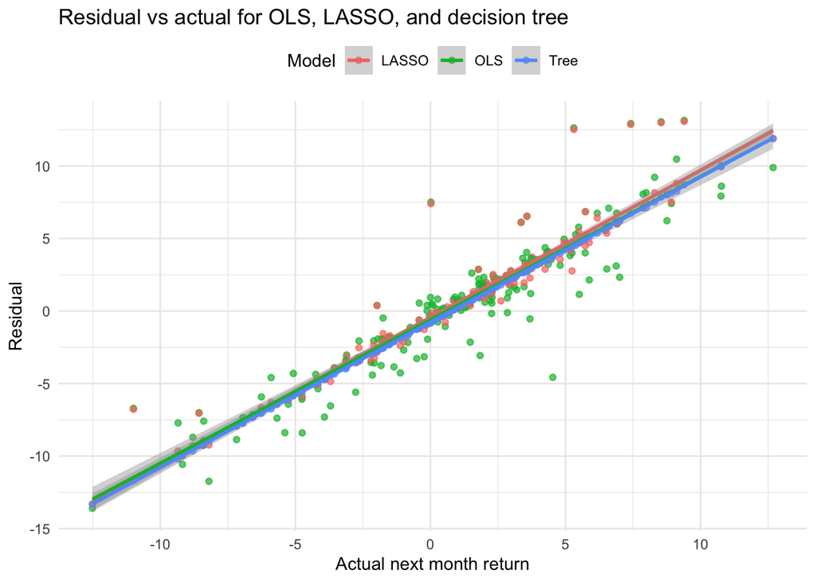

```r
Residual_long <- Testing_result %>%
  tidyr::pivot_longer(
    cols = c(fitted_return_OLS, fitted_return_LASSO, fitted_return_Tree),
    names_to = "Model",
    values_to = "Fitted"
  ) %>%
  dplyr::mutate(
    Model    = dplyr::recode(Model,
                             fitted_return_OLS   = "OLS",
                             fitted_return_LASSO = "LASSO",
                             fitted_return_Tree  = "Tree"),
    Residual = actual_return - Fitted
  )

ggplot(Residual_long,
       aes(x = actual_return, y = Residual, color = Model)) +
  geom_point(alpha = 0.7) +
  geom_smooth(method = "lm", se = TRUE) +
  labs(
    x = "Actual next month return",
    y = "Residual",
    color = "Model",
    title = "Residual vs actual for OLS, LASSO, and decision tree"
  ) +
  theme_minimal() +
  theme(legend.position = "top")
```

## Trading strategies from model forecasts

We build very simple trading rules:

- go long the index next month if the model’s forecast is positive
- sit in cash (0%) if the forecast is negative or zero

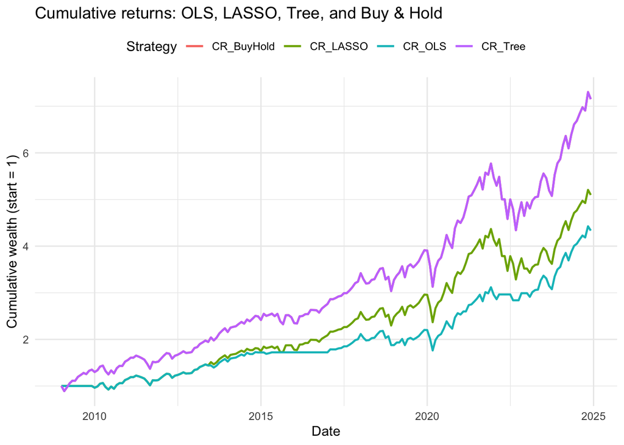

```r
Trading_Strategy <- Testing_result %>%
  dplyr::mutate(
    Trade_OLS    = (fitted_return_OLS   > 0),
    Trade_LASSO  = (fitted_return_LASSO > 0),
    Trade_Tree   = (fitted_return_Tree  > 0),
    ret_OLS      = Trade_OLS   * actual_return,
    ret_LASSO    = Trade_LASSO * actual_return,
    ret_Tree     = Trade_Tree  * actual_return
  )

Trading_Strategy$CR_OLS      <- NA_real_
Trading_Strategy$CR_LASSO    <- NA_real_
Trading_Strategy$CR_Tree     <- NA_real_
Trading_Strategy$CR_BuyHold  <- NA_real_

Trading_Strategy$CR_OLS[1]      <- 1
Trading_Strategy$CR_LASSO[1]    <- 1
Trading_Strategy$CR_Tree[1]     <- 1
Trading_Strategy$CR_BuyHold[1]  <- 1

for (i in 2:nrow(Trading_Strategy)) {
  Trading_Strategy$CR_OLS[i] <-
    Trading_Strategy$CR_OLS[i - 1] * (1 + Trading_Strategy$ret_OLS[i]   / 100)
  Trading_Strategy$CR_LASSO[i] <-
    Trading_Strategy$CR_LASSO[i - 1] * (1 + Trading_Strategy$ret_LASSO[i] / 100)
  Trading_Strategy$CR_Tree[i] <-
    Trading_Strategy$CR_Tree[i - 1] * (1 + Trading_Strategy$ret_Tree[i]   / 100)
  Trading_Strategy$CR_BuyHold[i] <-
    Trading_Strategy$CR_BuyHold[i - 1] * (1 + Trading_Strategy$actual_return[i] / 100)
}

Trading_long <- Trading_Strategy %>%
  dplyr::select(predicting_date, CR_OLS, CR_LASSO, CR_Tree, CR_BuyHold) %>%
  tidyr::pivot_longer(
    -predicting_date,
    names_to = "Strategy",
    values_to = "CR"
  )

ggplot(Trading_long,
       aes(x = predicting_date, y = CR, color = Strategy)) +
  geom_line(linewidth = 0.8) +
  theme_minimal() +
  labs(
    title = "Cumulative returns: OLS, LASSO, Tree, and Buy & Hold",
    x = "Date",
    y = "Cumulative wealth (start = 1)"
  ) +
  theme(legend.position = "top")
```

## Summary statistics table

```r
final_cr <- Trading_Strategy %>%
  summarise(
    CR_OLS     = dplyr::last(CR_OLS),
    CR_LASSO   = dplyr::last(CR_LASSO),
    CR_Tree    = dplyr::last(CR_Tree),
    CR_BuyHold = dplyr::last(CR_BuyHold)
  )

print(final_cr)
```

```
## # A tibble: 1 × 4
##   CR_OLS CR_LASSO CR_Tree CR_BuyHold
##    <dbl>    <dbl>   <dbl>      <dbl>
## 1   4.33     5.10    7.15       7.15
```

```r
avg_monthly <- Trading_Strategy %>%
  summarise(
    avg_ret_OLS     = mean(ret_OLS),
    avg_ret_LASSO   = mean(ret_LASSO),
    avg_ret_Tree    = mean(ret_Tree),
    avg_ret_BuyHold = mean(actual_return)
  )

print(avg_monthly)
```

```
## # A tibble: 1 × 4
##   avg_ret_OLS avg_ret_LASSO avg_ret_Tree avg_ret_BuyHold
##         <dbl>         <dbl>        <dbl>           <dbl>
## 1       0.828         0.934         1.08            1.08
```

## Python EZ PPO backtest via `src/eval.py` (through `ez_runner.py`)

This chunk shows *how* to call the Python backtest once `ez_runner.py` is wired to `src/eval.backtest_deterministic`. It assumes:

- `run_ez_eval(retrain = FALSE)` returns a list with two elements:
  - `train`: a list with `stats` and `paths`
  - `test`: a list with `stats` and `paths`
- each `paths` contains numeric vectors `wealth`, `cons`, and `actions` for that split

```r
# Make sure use_python(...) is set in the packages chunk
# and ez_runner.py has been source_python()'d

ez_eval <- run_ez_eval(retrain = FALSE)
```

[output not shown]

[output cut: 85 more lines]

```
##  45842.67804316 46513.87642486 46629.29096009 49647.43527285
##  51193.35044985 50286.33789148 47836.37253394 46784.8971292
##  50957.08949222 53210.83110135 54056.60174547 56852.38580725
##  58615.81622276 56176.45881477 58874.06075408 60915.1492123
##  61604.72666571 63011.38655721 64283.95787091 63647.69162763]
## Deterministic evaluation on test split:
##   split: test
##   initial_wealth: 10000.0
##   final_wealth: 63647.69162762636
##   pnl: 5.364769162762636
##   cagr: 0.12262941168330865
##   max_drawdown: -0.24770199748896915
##   calmar: 0.49506831970044846
##   V0_hat: 0.42399581270296904
##   n_steps: 192
```

```r
str(ez_eval)
```

```
## List of 2
##  $ :List of 2
##   ..$ stats:List of 9
##   .. ..$ split         : chr "train"
##   .. ..$ initial_wealth: num 10000
##   .. ..$ final_wealth  : num 59205
##   .. ..$ pnl           : num 4.92
##   .. ..$ cagr          : num 0.0769
##   .. ..$ max_drawdown  : num -0.463
##   .. ..$ calmar        : num 0.166
##   .. ..$ V0_hat        : num 0.659
##   .. ..$ n_steps       : int 288
##   ..$ paths:List of 4
##   .. ..$ wealth : num [1:288(1d)] 10000 10224 10981 11076 11044 ...
##   .. ..$ cons   : num [1:287(1d)] 0.01 0.0102 0.011 0.0111 0.011 ...
##   .. ..$ z      : num [1:287(1d)] 0.87 0.97 1.011 0.752 0.739 ...
##   .. ..$ actions: num [1:287(1d)] 2.28e-32 1.20e-33 1.01e-37 6.45e-33 5.51e-13 ...
##  $ :List of 2
##   ..$ stats:List of 9
##   .. ..$ split         : chr "test"
##   .. ..$ initial_wealth: num 10000
##   .. ..$ final_wealth  : num 63648
##   .. ..$ pnl           : num 5.36
##   .. ..$ cagr          : num 0.123
##   .. ..$ max_drawdown  : num -0.248
##   .. ..$ calmar        : num 0.495
##   .. ..$ V0_hat        : num 0.424
##   .. ..$ n_steps       : int 192
##   ..$ paths:List of 4
##   .. ..$ wealth : num [1:192(1d)] 10000 10078 9215 8202 8902 ...
##   .. ..$ cons   : num [1:191(1d)] 0.01 0.01008 0.00921 0.0082 0.0089 ...
##   .. ..$ z      : num [1:191(1d)] 0.751 0.817 0.731 0.75 0.818 ...
##   .. ..$ actions: num [1:191(1d)] 2.74e-26 3.22e-33 2.96e-38 1.86e-31 3.35e-30 ...
```

```r
# first element = train, second element = test
ez_test <- ez_eval[[2]]

# wealth path from Python (includes initial wealth at index 1)
ez_test_wealth <- as.numeric(ez_test$paths$wealth)

# scale to start at 1, then drop the initial point so length = # of test months
CR_EZ_full <- ez_test_wealth / ez_test_wealth[1]
CR_EZ <- CR_EZ_full[-1]

# Align with R-side TEST window

# Attach sample_set to Trading_Strategy via date, then keep only "test"
Trading_Strategy_test <- Trading_Strategy %>%
  dplyr::left_join(
    Total_data %>% dplyr::select(predicting_date, sample_set),
    by = "predicting_date"
  ) %>%
  dplyr::filter(sample_set == "test") %>%
  dplyr::arrange(predicting_date)

# Sanity check lengths
length(CR_EZ)
```

```
## [1] 191
```

```r
nrow(Trading_Strategy_test)
```

```
## [1] 192
```

```r
# If lengths differ slightly, trim to the min
L <- min(length(CR_EZ), nrow(Trading_Strategy_test))

CR_EZ <- CR_EZ[seq_len(L)]
Trading_Strategy_test <- Trading_Strategy_test %>%
  dplyr::slice(seq_len(L))

# Re-base all cumulative return series to 1 at the start of TEST period
rebase_to_one <- function(x) x / x[1]

Trading_Strategy_test <- Trading_Strategy_test %>%
  dplyr::mutate(
    CR_OLS     = rebase_to_one(CR_OLS),
    CR_LASSO   = rebase_to_one(CR_LASSO),
    CR_Tree    = rebase_to_one(CR_Tree),
    CR_BuyHold = rebase_to_one(CR_BuyHold)
  )

# Build LONG data: baseline strategies + EZ as its own rows

# CR_BuyHold, CR_OLS, CR_LASSO, CR_Tree

# Baseline R models + Buy & Hold
Trading_long_base <- Trading_Strategy_test %>%
  dplyr::select(predicting_date,
                CR_BuyHold, CR_OLS, CR_LASSO, CR_Tree) %>%
  tidyr::pivot_longer(
    cols = -predicting_date,
    names_to = "Strategy",
    values_to = "CR"
  )

# EZ PPO series
ez_df <- tibble::tibble(
  predicting_date = Trading_Strategy_test$predicting_date,
  Strategy        = "CR_EZ",
  CR              = CR_EZ
)

# Combine
Trading_long_EZ <- dplyr::bind_rows(Trading_long_base, ez_df)

# Optional sanity check
print(table(Trading_long_EZ$Strategy))
```

```
##
## CR_BuyHold      CR_EZ   CR_LASSO     CR_OLS    CR_Tree
##        191        191        191        191        191
```

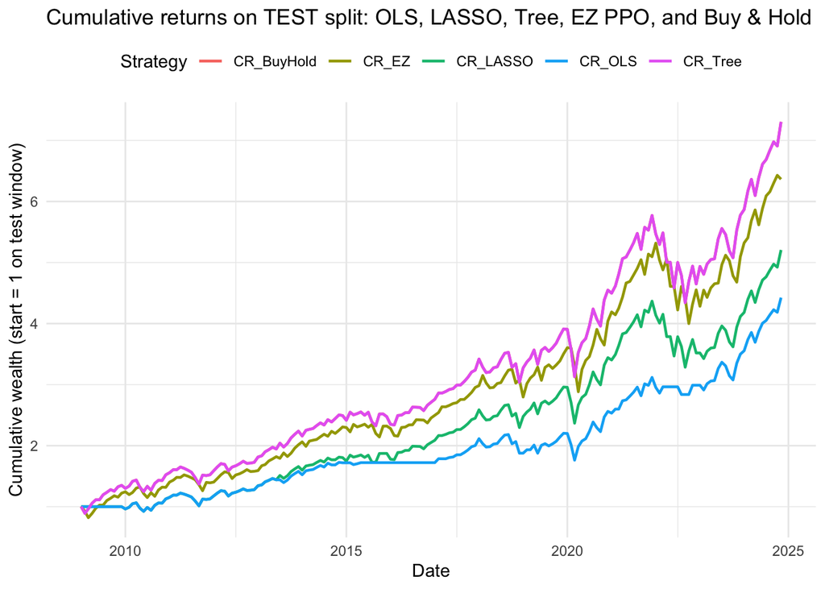

```r
ggplot(Trading_long_EZ,
       aes(x = predicting_date, y = CR, color = Strategy)) +
  geom_line(linewidth = 0.8) +
  theme_minimal() +
  labs(
    title = "Cumulative returns on TEST split: OLS, LASSO, Tree, EZ PPO, and Buy & Hold",
    x = "Date",
    y = "Cumulative wealth (start = 1 on test window)"
  ) +
  theme(legend.position = "top")
```

```r
# Make sure use_python(...) is set in the packages chunk
# and ez_runner.py has been source_python()'d

ez_eval <- run_ez_eval(retrain = FALSE)
```

[output not shown]

[output cut: 85 more lines]

```
##  45842.67804316 46513.87642486 46629.29096009 49647.43527285
##  51193.35044985 50286.33789148 47836.37253394 46784.8971292
##  50957.08949222 53210.83110135 54056.60174547 56852.38580725
##  58615.81622276 56176.45881477 58874.06075408 60915.1492123
##  61604.72666571 63011.38655721 64283.95787091 63647.69162763]
## Deterministic evaluation on test split:
##   split: test
##   initial_wealth: 10000.0
##   final_wealth: 63647.69162762636
##   pnl: 5.364769162762636
##   cagr: 0.12262941168330865
##   max_drawdown: -0.24770199748896915
##   calmar: 0.49506831970044846
##   V0_hat: 0.42399581270296904
##   n_steps: 192
```

```r
str(ez_eval)
```

```
## List of 2
##  $ :List of 2
##   ..$ stats:List of 9
##   .. ..$ split         : chr "train"
##   .. ..$ initial_wealth: num 10000
##   .. ..$ final_wealth  : num 59205
##   .. ..$ pnl           : num 4.92
##   .. ..$ cagr          : num 0.0769
##   .. ..$ max_drawdown  : num -0.463
##   .. ..$ calmar        : num 0.166
##   .. ..$ V0_hat        : num 0.659
##   .. ..$ n_steps       : int 288
##   ..$ paths:List of 4
##   .. ..$ wealth : num [1:288(1d)] 10000 10224 10981 11076 11044 ...
##   .. ..$ cons   : num [1:287(1d)] 0.01 0.0102 0.011 0.0111 0.011 ...
##   .. ..$ z      : num [1:287(1d)] 0.87 0.97 1.011 0.752 0.739 ...
##   .. ..$ actions: num [1:287(1d)] 2.28e-32 1.20e-33 1.01e-37 6.45e-33 5.51e-13 ...
##  $ :List of 2
##   ..$ stats:List of 9
##   .. ..$ split         : chr "test"
##   .. ..$ initial_wealth: num 10000
##   .. ..$ final_wealth  : num 63648
##   .. ..$ pnl           : num 5.36
##   .. ..$ cagr          : num 0.123
##   .. ..$ max_drawdown  : num -0.248
##   .. ..$ calmar        : num 0.495
##   .. ..$ V0_hat        : num 0.424
##   .. ..$ n_steps       : int 192
##   ..$ paths:List of 4
##   .. ..$ wealth : num [1:192(1d)] 10000 10078 9215 8202 8902 ...
##   .. ..$ cons   : num [1:191(1d)] 0.01 0.01008 0.00921 0.0082 0.0089 ...
##   .. ..$ z      : num [1:191(1d)] 0.751 0.817 0.731 0.75 0.818 ...
##   .. ..$ actions: num [1:191(1d)] 2.74e-26 3.22e-33 2.96e-38 1.86e-31 3.35e-30 ...
```

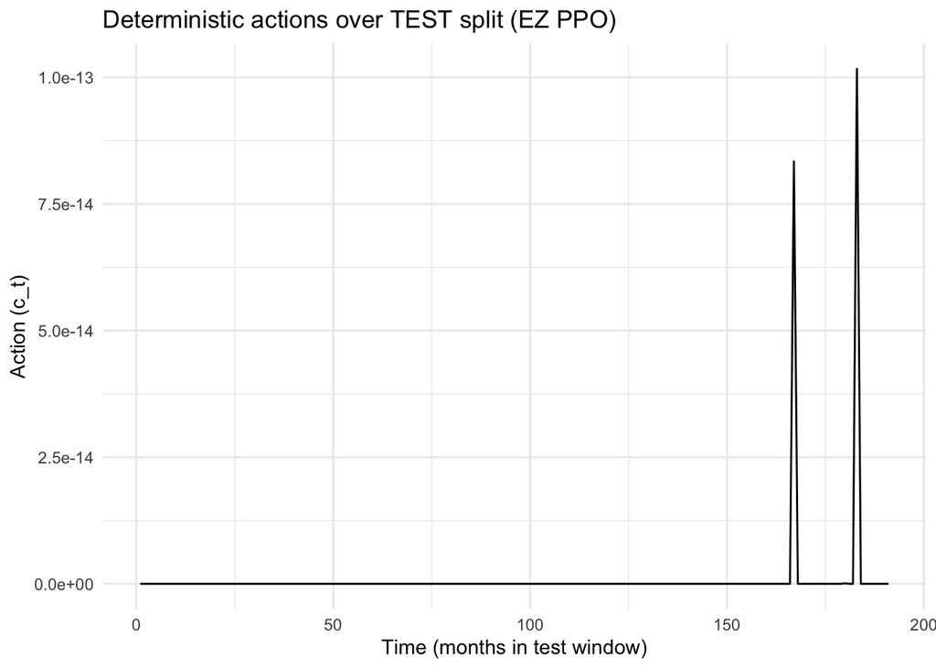

```r
# first element = train, second element = test
ez_test <- ez_eval[[2]]

# wealth path from Python (includes initial wealth at index 1)
ez_test_wealth <- as.numeric(ez_test$paths$wealth)

ez_test_actions <- as.numeric(ez_test$paths$actions)

tibble::tibble(
  t = seq_along(ez_test_actions),
  action = ez_test_actions
) %>%
  ggplot(aes(x = t, y = action)) +
  geom_line() +
  theme_minimal() +
  labs(
    title = "Deterministic actions over TEST split (EZ PPO)",
    x = "Time (months in test window)",
    y = "Action (c_t)"
  )
```

```r
# Low consumption rate means everything else is invested.


# scale to start at 1, then drop the initial point so length = # of test months
CR_EZ_full <- ez_test_wealth / ez_test_wealth[1]
CR_EZ <- CR_EZ_full[-1]

# Align with R-side TEST window

# Attach sample_set to Trading_Strategy via date, then keep only "test"
Trading_Strategy_test <- Trading_Strategy %>%
  dplyr::left_join(
    Total_data %>% dplyr::select(predicting_date, sample_set),
    by = "predicting_date"
  ) %>%
  dplyr::filter(sample_set == "test") %>%
  dplyr::arrange(predicting_date)

# Sanity check lengths
length(CR_EZ)
```

```
## [1] 191
```

```r
nrow(Trading_Strategy_test)
```

```
## [1] 192
```

```r
# If lengths differ slightly, trim to the min
L <- min(length(CR_EZ), nrow(Trading_Strategy_test))

CR_EZ <- CR_EZ[seq_len(L)]
Trading_Strategy_test <- Trading_Strategy_test %>%
  dplyr::slice(seq_len(L))

# Re-base all cumulative return series to 1 at the start of TEST period
rebase_to_one <- function(x) x / x[1]

Trading_Strategy_test <- Trading_Strategy_test %>%
  dplyr::mutate(
    CR_OLS     = rebase_to_one(CR_OLS),
    CR_LASSO   = rebase_to_one(CR_LASSO),
    CR_Tree    = rebase_to_one(CR_Tree),
    CR_BuyHold = rebase_to_one(CR_BuyHold)
  )

# Build LONG data: baseline strategies + EZ as its own rows

# CR_BuyHold, CR_OLS, CR_LASSO, CR_Tree

# Baseline R models + Buy & Hold
Trading_long_base <- Trading_Strategy_test %>%
  dplyr::select(predicting_date,
                CR_BuyHold) %>%
  tidyr::pivot_longer(
    cols = -predicting_date,
    names_to = "Strategy",
    values_to = "CR"
  )

# EZ PPO series
ez_df <- tibble::tibble(
  predicting_date = Trading_Strategy_test$predicting_date,
  Strategy        = "CR_EZ",
  CR              = CR_EZ
)

# Combine
Trading_long_EZ <- dplyr::bind_rows(Trading_long_base, ez_df)

# Optional sanity check
print(table(Trading_long_EZ$Strategy))
```

```
##
## CR_BuyHold      CR_EZ
##        191        191
```

[figure not shown]

```r
ggplot(Trading_long_EZ,
       aes(x = predicting_date, y = CR, color = Strategy)) +
  geom_line(linewidth = 0.8) +
  theme_minimal() +
  labs(
    title = "Cumulative returns on TEST split: OLS, LASSO, Tree, EZ PPO, and Buy & Hold",
    x = "Date",
    y = "Cumulative wealth (start = 1 on test window)"
  ) +
  theme(legend.position = "top")
```